# Differential Protein Expression Analysis

Vishnu Ramasubramanian

2025-02-03

# 1 Introduction

This document outlines the workflow for differential enrichment analysis of Mass Spectrometer (MS) proteomics data using the **DEP** package in R. Three comparisons are analyzed:

1. **MO vs. TNB**
2. **Bert vs. TN (CRISPR)**
3. **Bert vs. TN1 (CRISPR)** & **Bert vs. TN2 (CRISPR)**

For the second comparison , TN lines WPT673.7.8.8 & WPT673.7.12.5 are considered the same TN line with 4 replicates for comparison with Bert. Whereas for comparison 3, TN lines WPT673.7.8.8 & WPT673.7.12.5 are considered as distinct with 2 replicates each for comparison with Bert.

# 2 Objective

The objective of this analysis is to compare the protein expression profile of‘conventionally-bred triple-mutant lines_vs_recurrent parents’ and ‘crispr triple-mutants_vs_bert’. This analysis will help us assess crispr tech and conventionally generated mutant lines in terms of changes in the proteome landscape induced by these two different approaches to generating mutants.

# 3 Data Processing for DEP

## 3.1 Load Required Packages & Data

```r
if (!requireNamespace("BiocManager", quietly = TRUE)) install.packages("BiocManager")
if (!requireNamespace("DEP", quietly = TRUE)) BiocManager::install("DEP")
library(DEP)
library(SummarizedExperiment)
library(ggplot2)
library(ggrepel)
```

### 3.1.1 **Analysis: MO vs. TNB**

### 3.1.2 Load Data: Import MS2 protein level data for the samples generated using Spectronaut analysis from ‘.csv’ files

```r
setwd("C:/Users/ivanv/Desktop/UMN_Projects/Ritesh_DESeq_Analysis/TripleNullMutant_Paper_DEP/ProteinQuant/")

PrtnQuant <- read.csv("Supplemental table X1 Breeding lines TN .csv", header=TRUE)
dim(PrtnQuant)
```

```
## [1] 3460   13
```

### 3.1.3 **Analysis: Bert vs. TN (CRISPR)**

### 3.1.4 Load Data: Import MS2 protein level data for the samples generated using Spectronaut analysis from ‘.csv’ files

```r
setwd("C:/Users/ivanv/Desktop/UMN_Projects/Ritesh_DESeq_Analysis/TripleNullMutant_Paper_DEP/ProteinQuant/")

PrtnQuant2 <- read.csv("Supplemental table X2 CRISPR TN .csv", header=TRUE)
dim(PrtnQuant2)
```

```
## [1] 4603   20
```

## 3.2 Data Preprocessing for MO vs TNB

```r
PrtnQuant_Filt <- PrtnQuant[-c(1, which(duplicated(PrtnQuant[, 1]))), 1:5]
colnames(PrtnQuant_Filt)[1] <- "ID"

# Create sample annotation
treatment_conditions <- c("Control", "Control", "Mutant", "Mutant")
replicates <- c(1, 2, 1, 2)
sample_anno <- data.frame(label = colnames(PrtnQuant_Filt)[2:5], condition = treatment_conditions, replicate = replicates)

PrtnQuant_Filt <- make_unique(PrtnQuant_Filt, names="ID", ids="ID")
PrtnQuant_Filt[, 2:5] <- lapply(PrtnQuant_Filt[, 2:5], as.numeric)
```

### 3.2.1 Create Summarized Experiment Object

```r
data_se <- make_se(proteins_unique = PrtnQuant_Filt, columns = c(2:5), expdesign = sample_anno)
```

### 3.2.2 Quality checks for presence of proteins

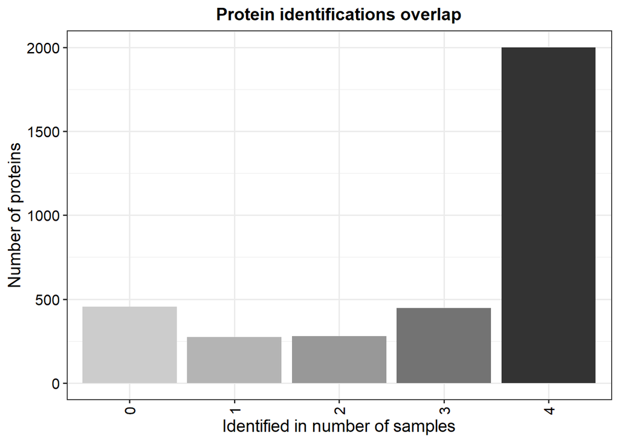

```r
plot_frequency(data_se)
```

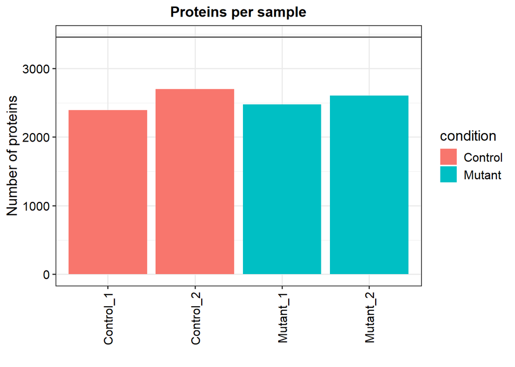

```r
plot_numbers(data_se)
```

### 3.2.3 Normalization using ‘vsn’ method

Normalize data and visualize mean-SD relationship for nearly horizontal mean SD line. In addition, compare distributions of pre-normalized and svn-normalized data

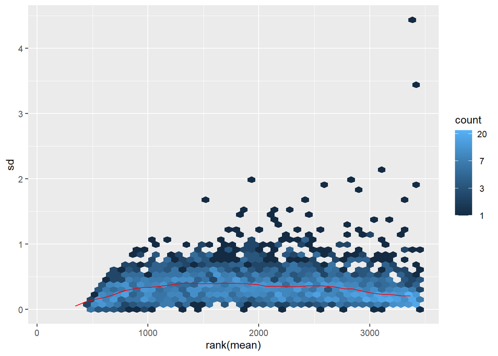

```r
data_se_norm <- normalize_vsn(data_se)
meanSdPlot(data_se_norm)
```

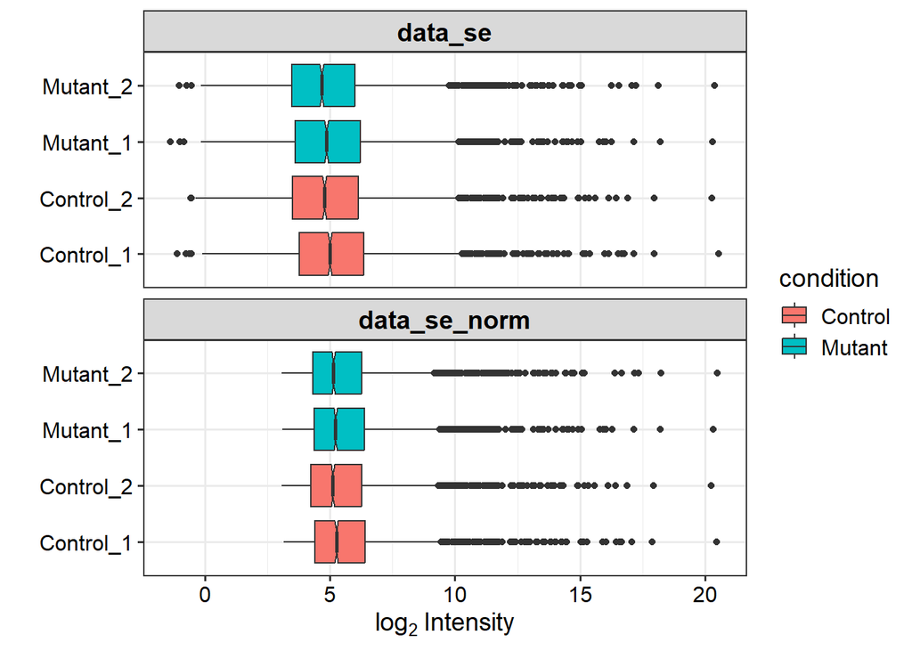

```r
plot_normalization(data_se, data_se_norm)
```

### 3.2.4 Filtering

```r
data_se_norm_filt <- filter_missval(data_se_norm, thr = 0.5)
```

### 3.2.5 Missing value imputation

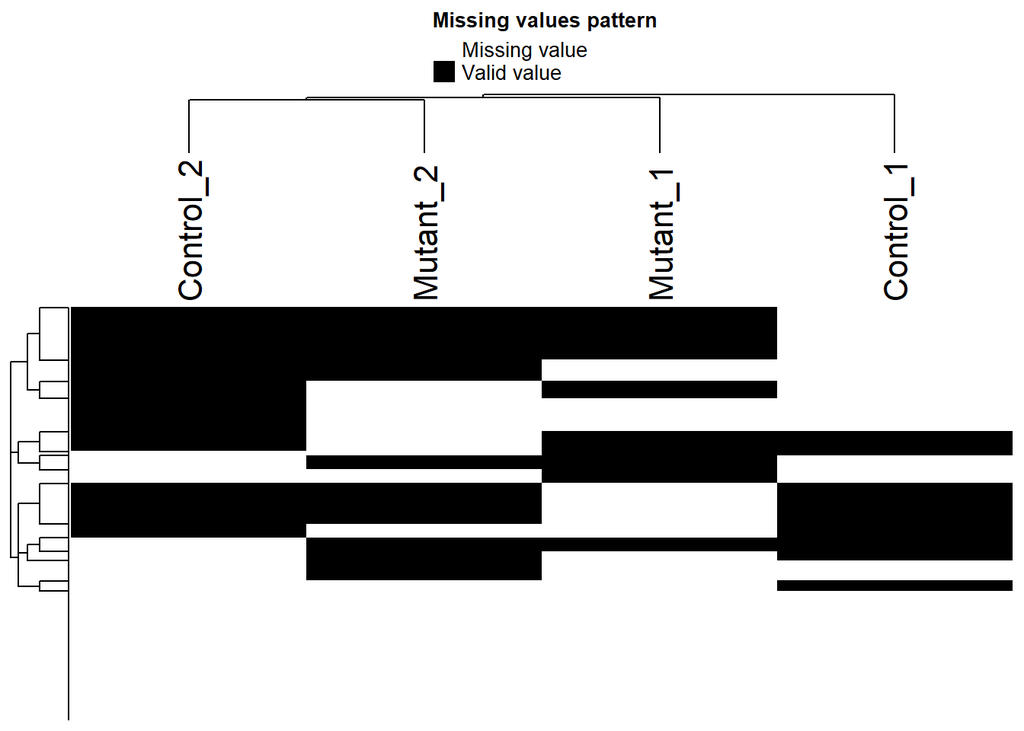

```r
plot_missval(data_se_norm)
```

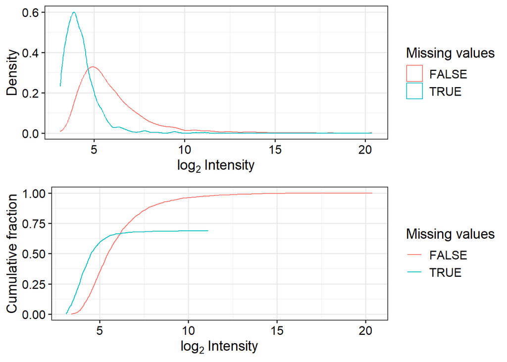

```r
plot_detect(data_se_norm)
```

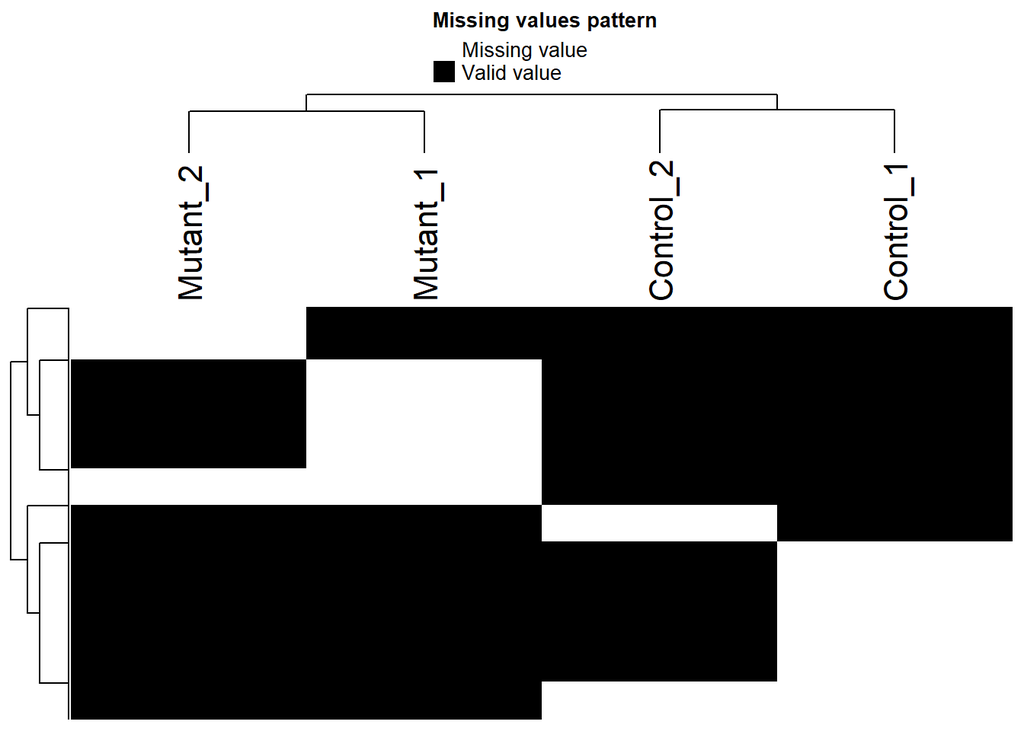

```r
plot_missval(data_se_norm_filt)
```

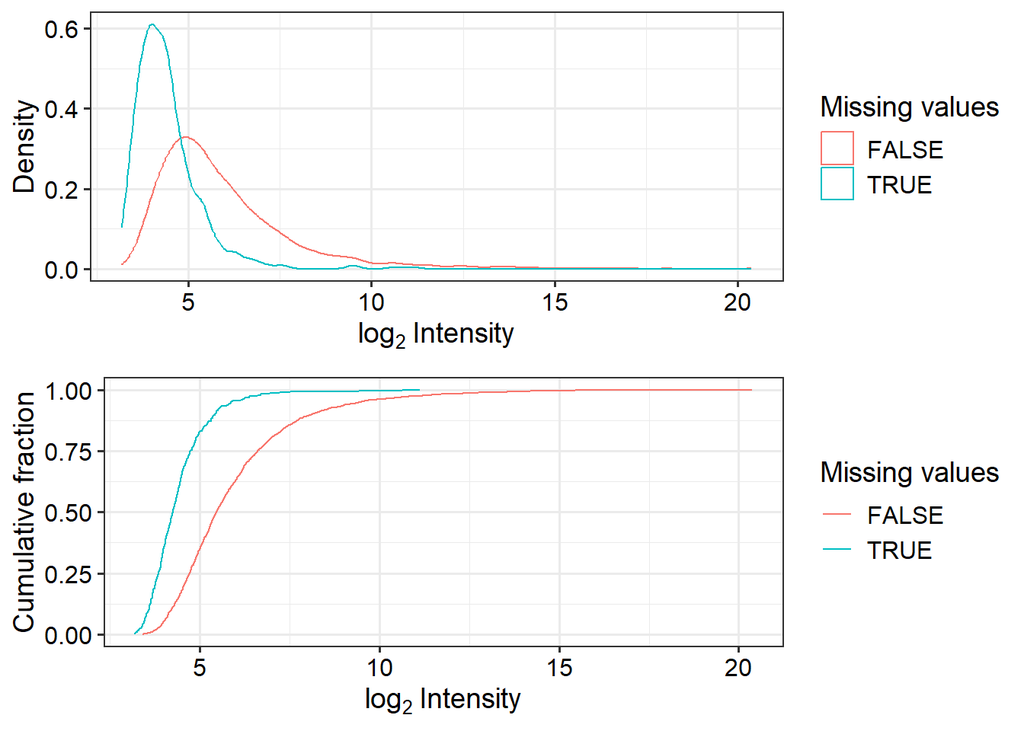

```r
plot_detect(data_se_norm_filt)
```

### 3.2.6 imputation

```r
#For missing at random ('MAR') data a Knn or MLE
# For missing not at random ('MNAR'),MinProb (QRILC)

# data_se_norm_imp0 <- impute(data_se_norm_filt, fun = "MinProb", q = 0.01)

data_se_norm_imp1 <- impute(data_se_norm_filt, fun = "knn", rowmax=0.9)
```

```
## Cluster size 2545 broken into 2177 368
## Cluster size 2177 broken into 1140 1037
## Done cluster 1140
## Done cluster 1037
## Done cluster 2177
## Done cluster 368
```

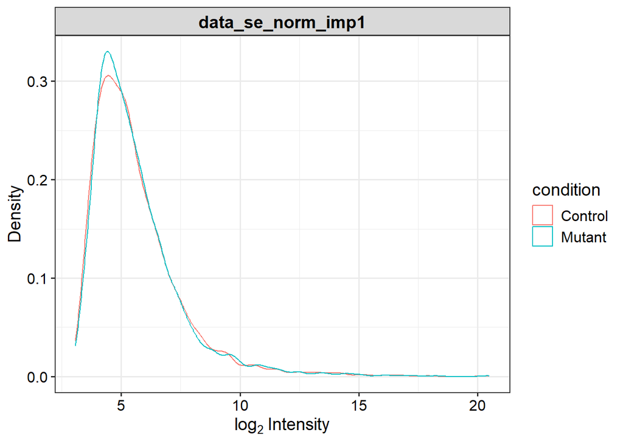

```r
plot_imputation(data_se_norm_imp1)
```

## 3.3 Data Preprocessing for Bert vs Crispr TN

```r
PrtnQuant2_Filt <- PrtnQuant2[-c(1, which(duplicated(PrtnQuant2[, 1]))), 1:9]

# Ensure no duplicates and filter relevant columns

dim(PrtnQuant2_Filt)  # Check dimensions after filtering
```

```
## [1] 4597    9
```

```r
colnames(PrtnQuant2_Filt)[1] <- "ID"
colnames(PrtnQuant2_Filt)[2:5] <- gsub("Biological.", "", colnames(PrtnQuant2_Filt)[2:5])
colnames(PrtnQuant2_Filt)[2:5] <- gsub("\\..Control.*.", "", colnames(PrtnQuant2_Filt)[2:5])




PrtnQuant2_Filt <- make_unique(PrtnQuant2_Filt,names="ID",ids="ID")
for(i in 2:9){
  PrtnQuant2_Filt[,i] <- as.numeric(PrtnQuant2_Filt[,i])
}
```

#### 3.3.0.1 Create Summarized Experiment Object IIa

```r
sample_anno2a <- data.frame(
  label = colnames(PrtnQuant2_Filt)[2:9],
  condition = c("WT", "WT", "WT", "WT", "TN", "TN", "TN", "TN"),
  replicate = c(1,2,3,4,1,2,3,4)
)
```

```r
data_se2a <- make_se(proteins_unique = PrtnQuant2_Filt, columns = c(2:9), expdesign = sample_anno2a)
```

### 3.3.1 Data quality checks 2a

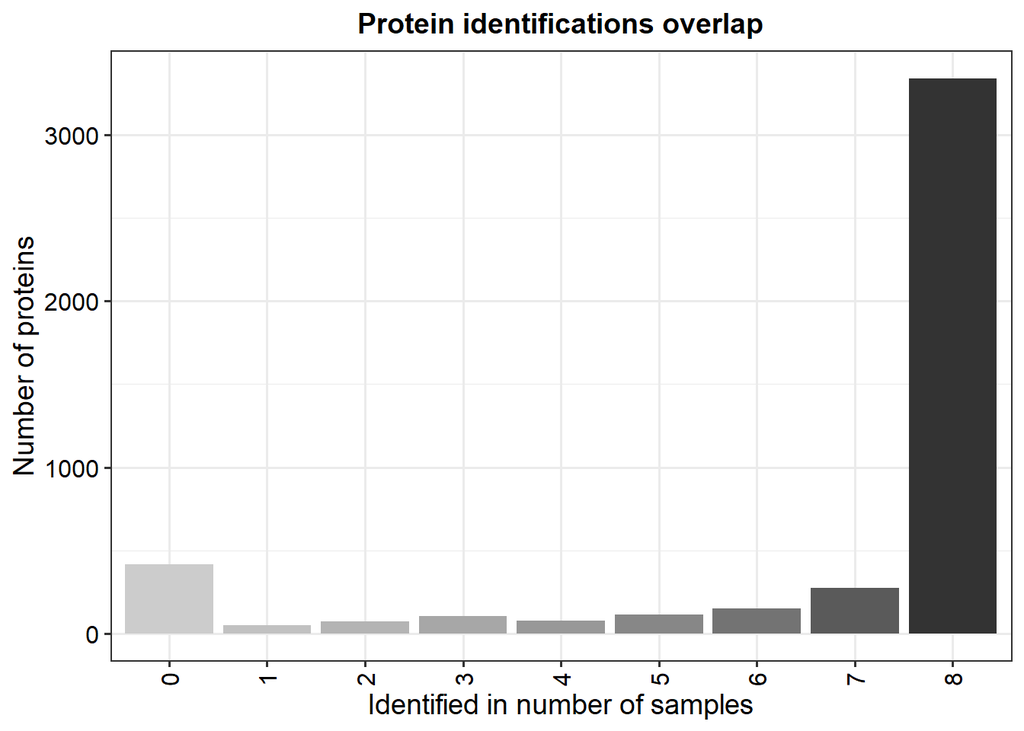

```r
plot_frequency(data_se2a)
```

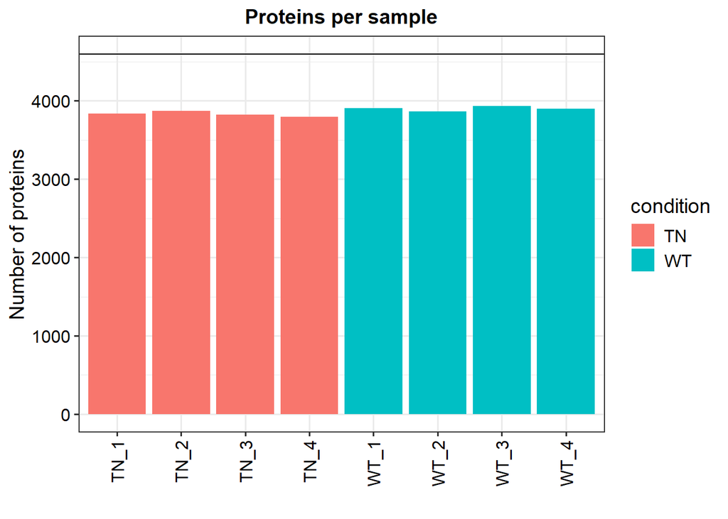

```r
plot_numbers(data_se2a)
```

### 3.3.2 Normalization 2a

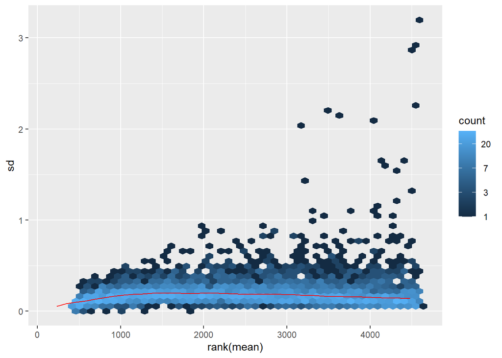

```r
data_se_norm2a <- normalize_vsn(data_se2a)
meanSdPlot(data_se_norm2a)
```

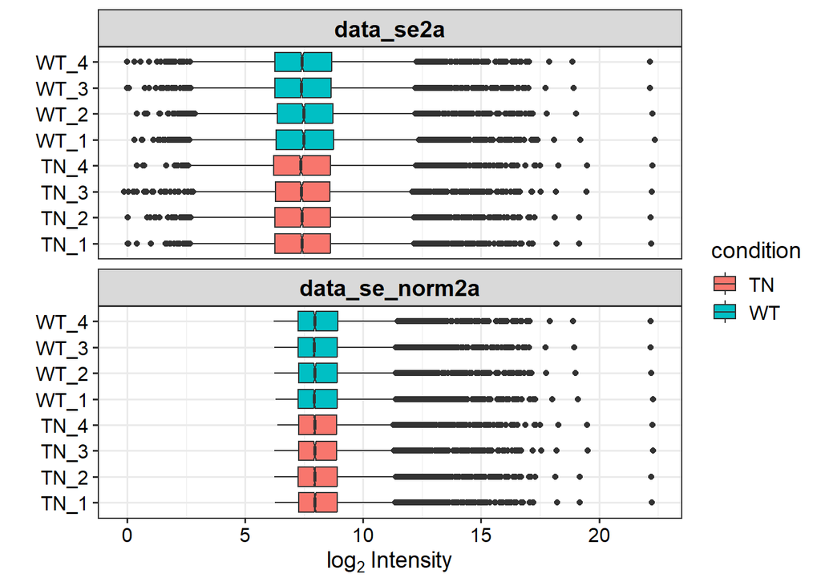

```r
plot_normalization(data_se2a, data_se_norm2a)
```

### 3.3.3 Filtering

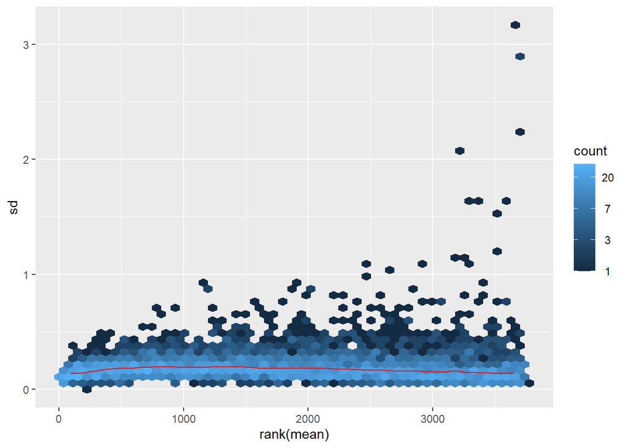

```r
data_se_norm_filt2a <- filter_missval(data_se_norm2a, thr = 0.5)
meanSdPlot(data_se_norm_filt2a)
```

### Impute missing values

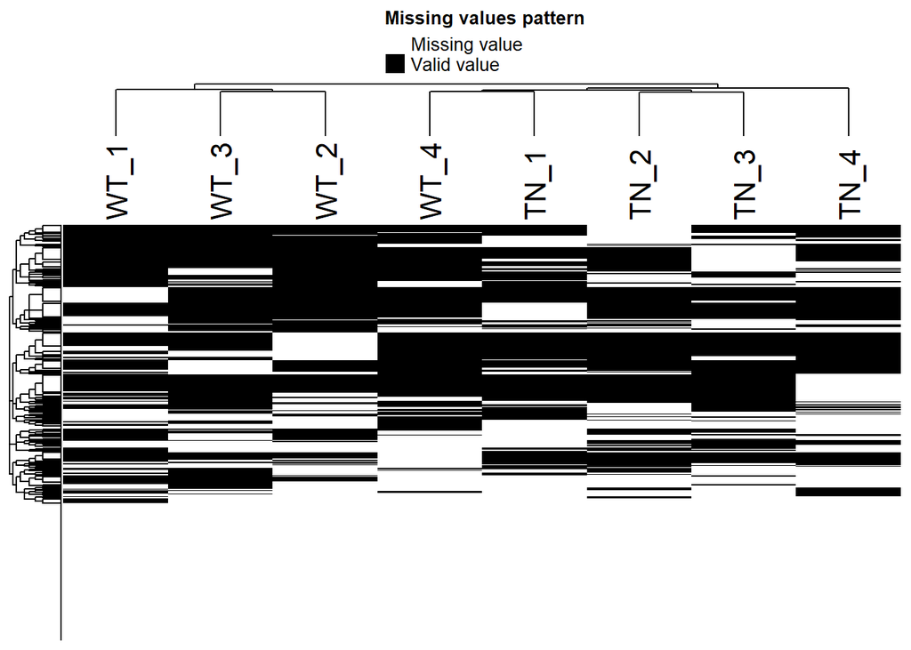

```r
###
plot_missval(data_se_norm2a)
```

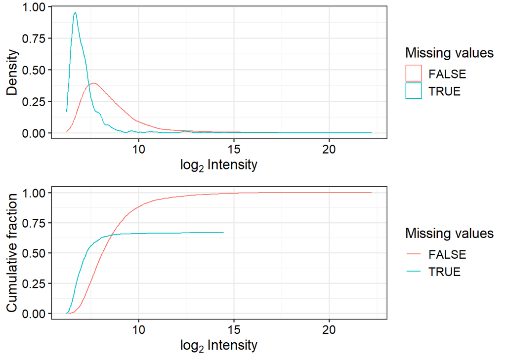

```r
plot_detect(data_se_norm2a)
```

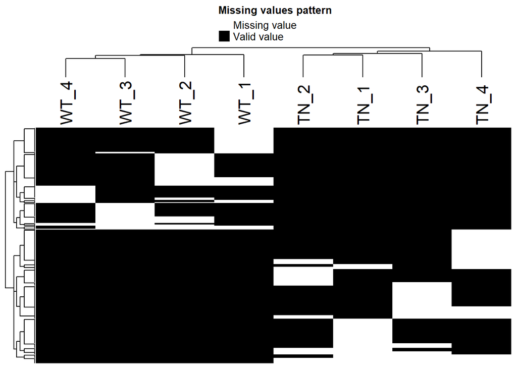

```r
###

plot_missval(data_se_norm_filt2a)
```

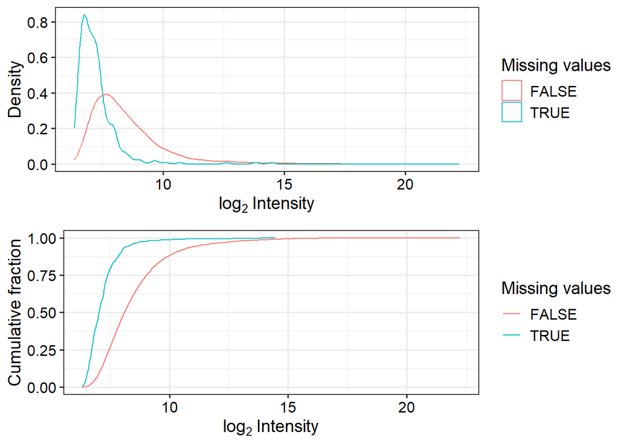

```r
plot_detect(data_se_norm_filt2a)
```

### 3.3.4 Imputation II a

```r
# For missing not at random ('MNAR'),MinProb (QRILC)

 data_se_norm_imp2a <- impute(data_se_norm_filt2a, fun = "MinProb", q = 0.01)
```

```
## [1] 0.1742397
```

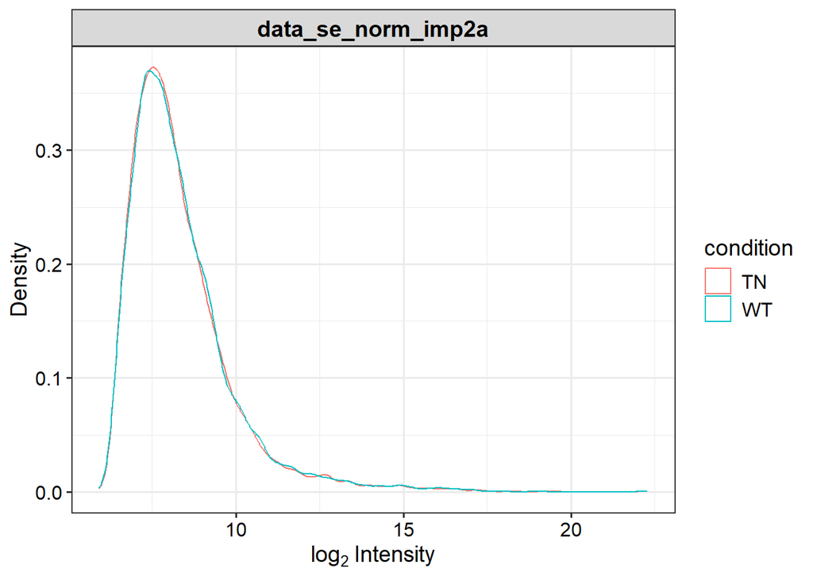

```r
# For missing at random ('MAR') data a Knn or MLE

# data_se_norm_imp2a <- impute(data_se_norm_filt2a, fun = "knn", rowmax=0.9)

 plot_imputation(data_se_norm_imp2a)
```

## 3.4 Data Preprocessing for Bert vs Crispr TN1 and Bert vs Crispr TN2

#### 3.4.0.1 Create Summarized Experiment Object IIb

```r
sample_anno2b <- data.frame(
  label = colnames(PrtnQuant2_Filt)[2:9],
  condition = c("WT", "WT", "WT", "WT", "TN1", "TN1", "TN2", "TN2"),
  replicate = c(1,2,3,4,1,2,1,2)
)
```

### 3.4.1 Create Summarized Experiment Object II b

```r
data_se2b <- make_se(proteins_unique = PrtnQuant2_Filt, columns = c(2:9), expdesign = sample_anno2b)
```

### 3.4.2 Data quality checks 2b

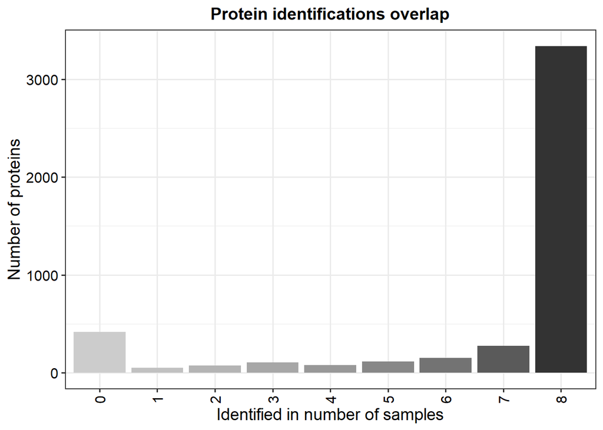

```r
plot_frequency(data_se2b)
```

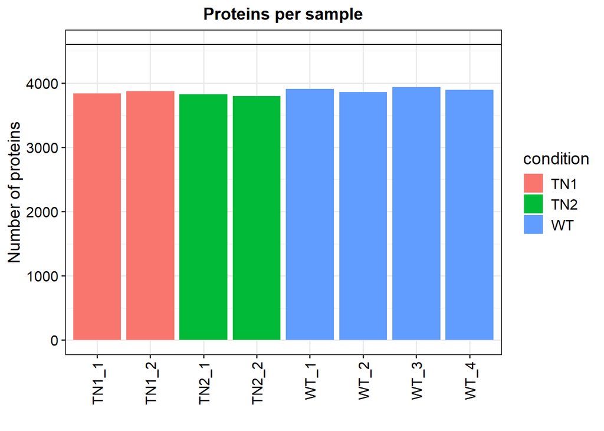

```r
plot_numbers(data_se2b)
```

### 3.4.3 Normalization 2b

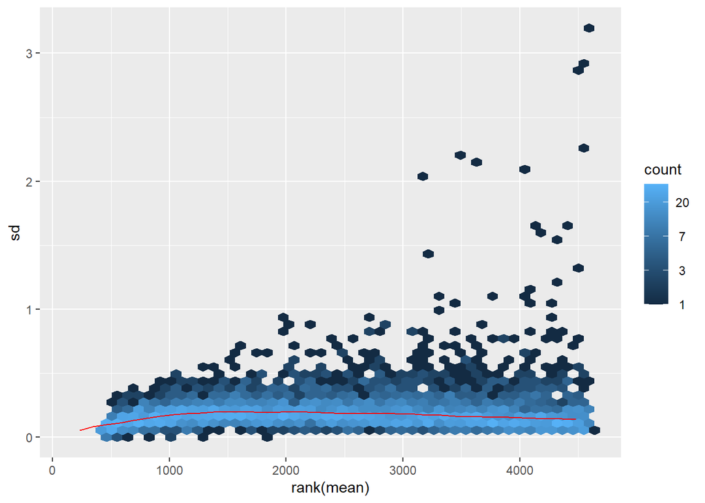

```r
data_se_norm2b <- normalize_vsn(data_se2b)
meanSdPlot(data_se_norm2b)
```

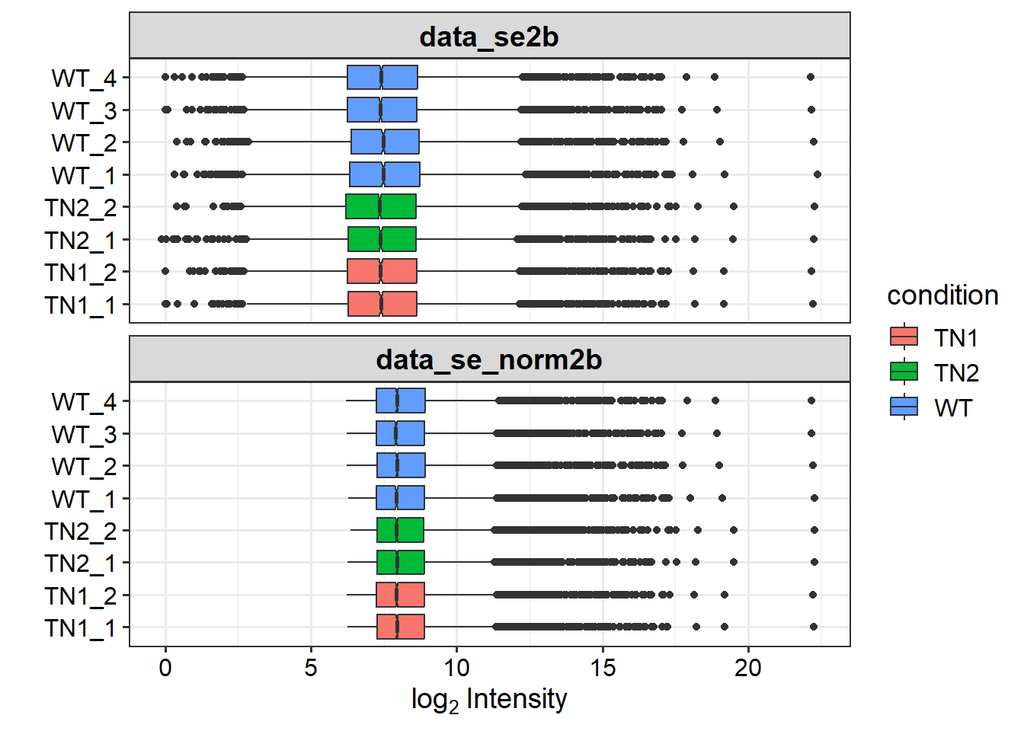

```r
plot_normalization(data_se2b, data_se_norm2b)
```

### 3.4.4 Filtering 2b

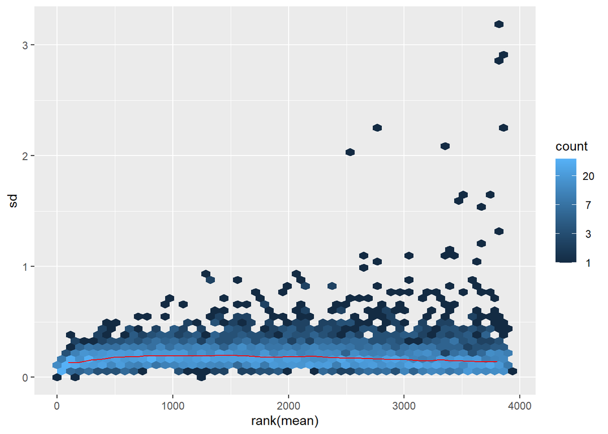

```r
data_se_norm_filt2b <- filter_missval(data_se_norm2b, thr = 0.5)
meanSdPlot(data_se_norm_filt2b)
```

### 3.4.5 Impute missing values 2b

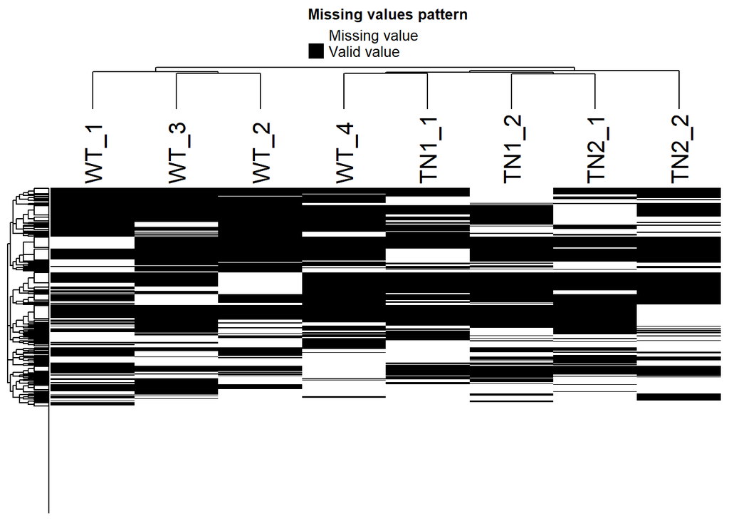

```r
###
plot_missval(data_se_norm2b)
```

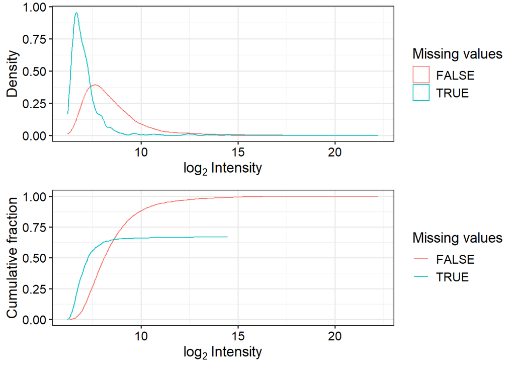

```r
plot_detect(data_se_norm2b)
```

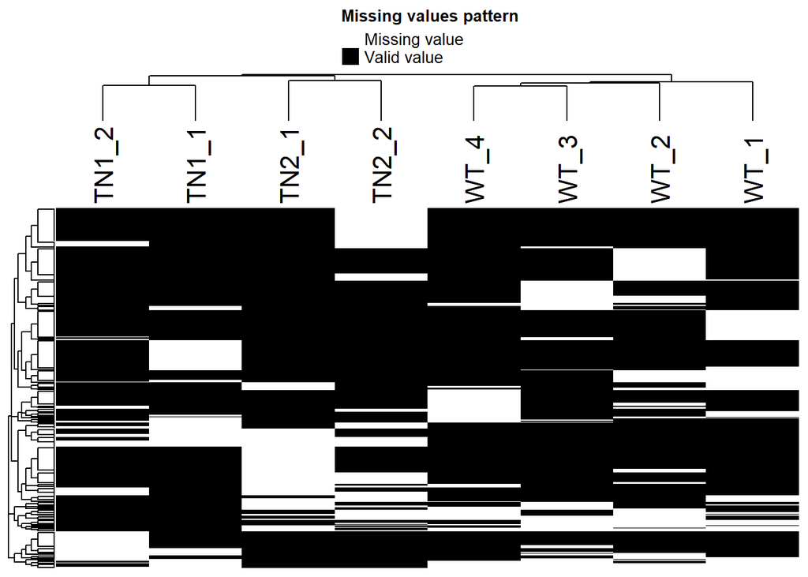

```r
###

plot_missval(data_se_norm_filt2b)
```

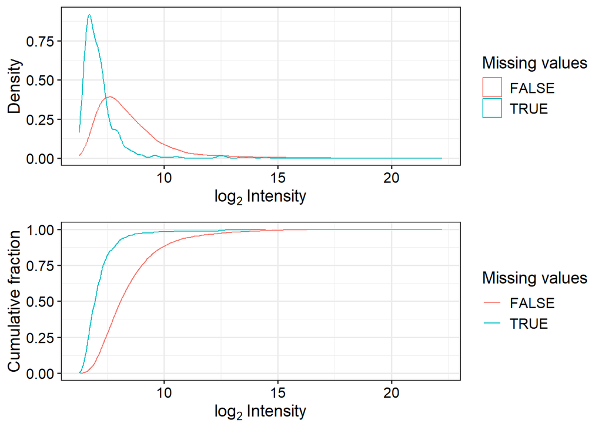

```r
plot_detect(data_se_norm_filt2b)
```

### 3.4.6 Imputation II b

```r
# For missing not at random ('MNAR'),MinProb (QRILC)

 data_se_norm_imp2b <- impute(data_se_norm_filt2b, fun = "MinProb", q = 0.01)
```

```
## [1] 0.1742828
```

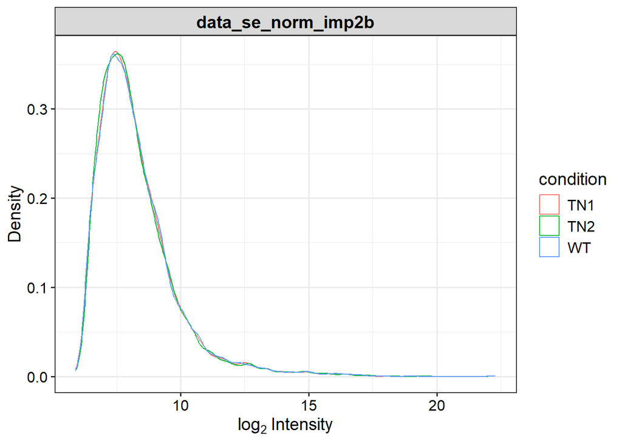

```r
# For missing at random ('MAR') data a Knn or MLE

# data_se_norm_imp2b <- impute(data_se_norm_filt2b, fun = "knn", rowmax=0.9)

 plot_imputation(data_se_norm_imp2b)
```

# 4 Differential Enrichment Analysis

## 4.1 DEP Analysis for mo_vs_tnb

```r
# data_diff <- test_diff(data_se_norm_imp, type = "control", control = "Control")
# dep <- add_rejections(data_diff, alpha = 0.05, lfc = 1)


data_diff1 <- test_diff(data_se_norm_imp1, type = "control", control = "Control")
dep1 <- add_rejections(data_diff1, alpha = 0.05, lfc = 1)
```

### 4.1.1 Heatmap for MO_vs_TNB analysis

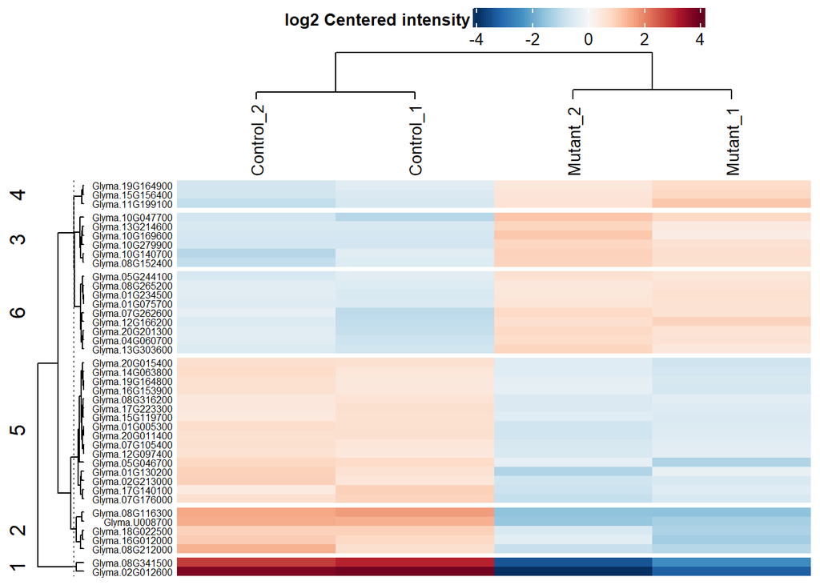

```r
plot_heatmap(dep1, type = "centered", kmeans = TRUE, k = 6, col_limit = 4)
```

### 4.1.2 PCA Plot for MO_vs_TNB analysis

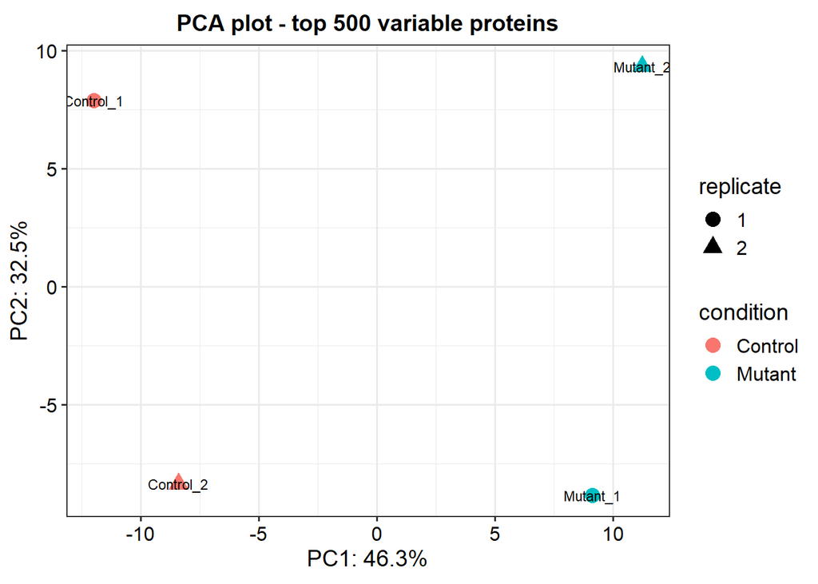

```r
plot_pca(dep1, x = 1, y = 2, label = TRUE, n = 500)
```